# Etap 6: Weryfikacja potrzeby i poprawny wybór transformacji/kodowania dla zmiennych zależnych i niezależnych

Michał Ciach, Ola Paluszyńska

25 maja 2017

# 1 Streszczenie wyników

W tym etapie przyjrzeliśmy się dokładniej zmiennym niezależnym odpowiadającym punktacji zadania (`score`), liczbie książek w domu (`no_of_books`) oraz wykształceniu matki i ojca (`mother_edu`, `father_edu`). Każda z wymienionych zmiennych jest jakościowa o kilku kategoriach, a więc włączając je do modelu możemy zastosować różnego rodzaju kodowanie i/lub transformację, których wybór wpływa na dopasowanie i wielkość modelu.

W przypadku zmiennej `score` zdecydowaliśmy się wykluczyć ze zbioru danych zadanie, dla którego skala tej zmiennej była inna niż w pozostałych przypadkach (zadanie to dopuszczało “Partial credit”). Dla `no_of_books` rozważyliśmy kodowanie ciągłe i łączenie niektórych poziomów, jednak żadne z nich nie okazało się lepsze od wyjściowego. W przypadku `father_edu` kodowanie ciągłe znacznie poprawiło jakość modelu, czego nie można powiedzieć o `mother_edu`. Z tego względu rozważyliśmy kontrasty wielomianowe i łączenie poziomów `mother_edu` na podstawie testu post-hoc Tukey’a, ale żadne z podejść nie poprawiło modelu pod względem kryteriów informacyjnych.

W drugiej części pracy rozważyliśmy transformacje zmiennej niezależnej Boxa-Coxa oraz logarytmiczne z przesunięciem. Na poprzednich etapach analizy wybraliśmy logarytmiczną z przesunięciem jako optymalną, jednak po licznych zmianach w wybranym modelu okazało się, że transformacja Boxa-Coxa obniża kryteria informacyjne prawie pięciokrotnie i prowadzi do niemalże symetrycznego rozkładu reszt (choć trochę zbyt spiczastego co powoduje wizualnie większą rozbieżność z rozkładem normalnym). Ostatecznie, kierując się kryteriami informacyjnymi, do dalszej analizy wybraliśmy transformację Boxa-Coxa z wykładnikiem 0.3434.

# 2 Wyjściowy model

Najpierw przypomnimy model będący efektem poprzednich etapów pracy.

## 2.1 Ładowanie danych

Poniżej ładujemy wybraną uprzednio próbkę szkół. Na etapie wyboru próbki rozważaliśmy przeprowadzanie analizy na co czwartej lub co dziesiątej szkole. Do tej pory używaliśmy większej z tych dwóch próbek, ale ze względu na wielkość modelu, do którego doszliśmy w poprzednim etapie, od tej pory ograniczymy się do mniejszej próbki (co dziesiąta szkoła), co umożliwi nam swobodne porównywanie wielu modeli o znacznych rozmiarach. Dla przejrzystości zmieniamy nazwy zmiennych wykorzystywanych w stworzonym przez nas na poprzednich etapach modelu, a następnie ustalamy poziomy bazowe tak jak wcześniej:

```r
load("Projekt_probka.rda")
probka <- probka[, c("time", "time.log", "task", "HEDRES", "CNT", "ST013Q01TA", "WEALTH", "BOOKID", "FISCED", "MISCED", "gender", "S")]
colnames(probka)[-(1:3)] <- c("edu_resources", "country", "no_of_books", "wealth", "book_id", "father_edu", "mother_edu", "gender", "score")
probka$country <- relevel(probka$country, ref = "POL")
probka$mother_edu <- relevel(probka$mother_edu, ref = "0")
probka$father_edu <- relevel(probka$father_edu, ref = "0")
probka$no_of_books <- factor(as.numeric(as.character(probka$no_of_books)), levels = c(-1, 1:6), labels = c("-1", "0-10", "11-25", "26-100", "101-200", "201-500", ">500"))
probka$no_of_books <- relevel(probka$no_of_books, ref="0-10")
probka$score <- relevel(probka$score, ref = "No credit")
probka$female <- probka$gender == "1"
```

## 2.2 Oszacowania modelu

Poniżej szacujemy parametry modelu wyjściowego. Warto zaznaczyć, że zastosowana przez nas transformacja zmiennej objaśnianej została wybrana przed dodaniem wielu ze zmiennych objaśniających, więc prawdopodobnie nie jest optymalna. Ponadto, oszacowany przez nas model ma bardzo dużo parametrów ze względu na występujące w nim zmienne jakościowe o wielu kategoriach i ich interakcje, a zatem warto rozważyć ich transformacje.

```r
modelBase <- lm(time.log ~ score*(task + edu_resources + no_of_books + wealth + book_id + father_edu) + mother_edu + female + country, data = probka)
anova(modelBase)
```

```
## Analysis of Variance Table
##
## Response: time.log
##                         Df Sum Sq Mean Sq F value Pr(>F)
## score                    3   1901     634 2279.64 <2e-16 ***
## task                    44   7722     175  631.25 <2e-16 ***
## edu_resources            1     49      49  174.93 <2e-16 ***
## no_of_books              6    136      23   81.47 <2e-16 ***
## wealth                   1    589     589 2119.79 <2e-16 ***
## book_id                 35   1594      46  163.83 <2e-16 ***
## father_edu               7     94      13   48.13 <2e-16 ***
## mother_edu               7     50       7   25.73 <2e-16 ***
## female                   1    116     116  418.30 <2e-16 ***
## country                 54   2116      39  140.96 <2e-16 ***
## score:task              80   5387      67  242.19 <2e-16 ***
## score:edu_resources      3    168      56  201.48 <2e-16 ***
## score:no_of_books       17    280      16   59.33 <2e-16 ***
## score:wealth             3     21       7   25.52 <2e-16 ***
## score:book_id           77    173       2    8.06 <2e-16 ***
## score:father_edu        21     46       2    7.89 <2e-16 ***
## Residuals           340997  94803       0
## ---
## Signif. codes:  0 '***' 0.001 '**' 0.01 '*' 0.05 '.' 0.1 ' ' 1
```

# 3 Kodowanie zmiennych niezależnych

## 3.1 Punktacja zadania

Punktacja zadania jest ważną zmienną w naszym modelu ze względu na to, że wchodzi w skład kilku interakcji. Jej rozkład w próbie jest następujący, w warstwach ze względu na zadanie:

```r
table(probka$task, probka$score)
```

```
##
##        No credit    -1 Full credit Partial credit
##   M00G      4260   298         297              0
##   M00K         0  4799           0              0
##   M033      1181    39        3721              0
##   M034      2944   215        1581              0
##   M155      3846 10324        5523              0
##   M192         0  4978           0              0
##   M273      2828    78        2025              0
##   M305      2964   110        1920              0
##   M406         0  9898           0              0
##   M408      3285    48        1600              0
##   M411      5254   412        4100              0
##   M420      2726    31        2174              0
##   M423      1186    34        3762              0
##   M442      3113   542        1161              0
##   M446      1752  5138        2937              0
##   M447      2063    92        2795              0
##   M462         0  4769           0              0
##   M464      3620   210         983              0
##   M474      1831    30        3080              0
##   M496      4642   190        5149              0
##   M559      1940    59        2893              0
##   M564      5264   121        4337              0
##   M571      2729   162        2004              0
##   M603      3118    72        1722              0
##   M800       571   176        4034              0
##   M803      3620   221        1011              0
##   M828      2636  5692        1370              0
##   M905       850  3818        2910              0
##   M906      1993  4913        2791              0
##   M909      6113   511        8074              0
##   M915      4323   401        5071              0
##   M919      2630   157        4790              0
##   M936       612  1238         279              0
##   M939      1176    64         780              0
##   M943      4503   843        2177              0
##   M948      1639   114        1482              0
##   M949      5081  4958        4607              0
##   M953      1476  7759        1951              0
##   M954      3371  4380        3587              0
##   M955      3644 10230         382            209
##   M961       608  2145         346              0
##   M967      1612   104         267              0
##   M982      8844   250       10693              0
##   M992      5356  5236        4187              0
##   M998      2802  5083        1648              0
```

Jak widać, kategoria “Partial credit” jest nie tylko bardzo mało liczna, ale przede wszystkim występuje tylko dla jednego zadania, a więc jest nietypowa. Z tego względu nie do końca wiemy co oznacza ta kategoria i jak się ma do ocen w innych zadaniach. Ostatecznie zdecydowaliśmy się usunąć z naszej próbki dane dotyczące zadania “M955”, ze względu na ważną rolę interakcji ze zmienną `score` w naszym modelu, która dla tego zadania mierzona jest w innej skali niż dla pozostałych.

```r
probka <- probka[probka$task != "M955", ]
probka$score <- droplevels(probka$score)
probka$task <- droplevels(probka$task)
modelBase <- lm(time.log ~ score*(task + edu_resources + no_of_books + wealth + book_id + father_edu) + mother_edu + female + country, data = probka)
crit_base <- c(AIC = AIC(modelBase), BIC = BIC(modelBase))
```

Następnie tworzymy tabelę z parametrami modelu z osobną kolumną `beta_score` uwzględniającą interakcję ze zmienną `score` (jest w niej suma danego parametru i odpowiedniego parametru dla zmiennej `score`), zapisujemy to w formie funkcji do ponownego użycia.

```r
coefs_score <- function(x){
  coefs <- data.frame(beta = x, variable = gsub("score.+:", "", names(x)), score = "No credit")
  coefs$score <- as.character(coefs$score)
  coefs$score[grep("score.+:", rownames(coefs))] <- rownames(coefs)[grep("score.+:", rownames(coefs))]
  coefs$score <- gsub("score", "", coefs$score)
  coefs$score <- gsub(":.+", "", coefs$score)
  coefs$score[c(1:3, grep("country", rownames(coefs)), grep("female", rownames(coefs)), grep("mother_edu", rownames(coefs)))] <- NA
  rownames(coefs) <- NULL
  coefs$score <- factor(coefs$score, levels = c("-1", "No credit", "Full credit"))
  coefs$beta_score <- NA
  coefs[grep("-1", as.character(coefs$score)), "beta_score"] <- coefs$beta[grep("-1", as.character(coefs$score))] + coefs$beta[2]
  coefs[grep("Full credit", as.character(coefs$score)), "beta_score"] <- coefs$beta[grep("Full credit", as.character(coefs$score))] + coefs$beta[3]
  coefs[grep("No credit", as.character(coefs$score)), "beta_score"] <- coefs$beta[grep("No credit", as.character(coefs$score))]
  coefs$variable <- as.character(coefs$variable)
  return(coefs)
}
coefs <- coefs_score(modelBase$coefficients)
```

## 3.2 Liczba książek

Zmienna `no_of_books` ma następujący rozkład w naszej próbce:

```r
table(probka$no_of_books)
```

```
##
##    0-10      -1   11-25  26-100 101-200 201-500    >500
##   60684    1677   60338   91893   51357   38741   22203
```

Widać, że zmienna ta ma aż siedem poziomów (-1 oznacza brak danych, poziom “0-10” jest bazowy), a odpowiadające jej parametry są następujące:

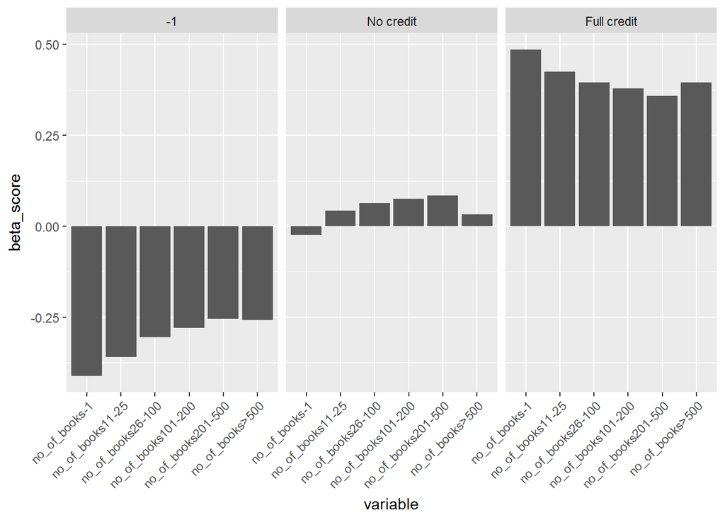

```r
df <- coefs[grep("no_of_books", coefs$variable), ]
df$variable <- factor(df$variable, levels = paste0("no_of_books", setdiff(levels(probka$no_of_books), "0-10")))
ggplot(df, aes(y = beta_score, x = variable)) + geom_bar(stat = "identity") + facet_wrap(~ score) + theme(axis.text.x=element_text(angle = 45, hjust = 1))
```

Na wykresie widzimy, że parametry dla zmiennej `no_of_books`zmieniają się monotonicznie dla kolejnych jej poziomów z wyjątkiem ostatniego (co ciekawe, w monotoniczność wpisuje się również kategoria -1 oznaczająca brak danych). Z tego względu sensownym wydaje się włączenie tej zmiennej do modelu jako ciągłej. W tym celu wygenerujemy zmienną `no_of_books_na` mówiącą, czy brakuje wartości dla `no_of_books`, a następnie nową zmienną `no_of_books_num`, w której zakodujemy wartości numeryczne jeśli takowe były i średnią w próbie, jeśli tych wartości nie było. Następnie do modelu włączamy obie nowe zmienne.

```r
probka$no_of_books <- relevel(probka$no_of_books, ref = "-1")
probka$no_of_books_na <- probka$no_of_books == "-1"
probka$no_of_books_num <- as.numeric(probka$no_of_books)
probka[probka$no_of_books_num == 1, "no_of_books_num"] <- mean(probka[probka$no_of_books_num != 1, "no_of_books_num"])
probka$no_of_books <- relevel(probka$no_of_books, ref = "0-10")
model <- lm(time.log ~ score*(task + edu_resources + no_of_books_num + no_of_books_na + wealth + book_id + father_edu) + mother_edu + female + country, data = probka)
anova(model)[grep("no_of_books", rownames(anova(model))),]
```

```
## Analysis of Variance Table
##
## Response: time.log
##                       Df Sum Sq Mean Sq F value  Pr(>F)
## no_of_books_num        1   44.2    44.2   158.2 < 2e-16 ***
## no_of_books_na         1    5.4     5.4    19.4 1.1e-05 ***
## score:no_of_books_num  2  265.7   132.8   475.4 < 2e-16 ***
## score:no_of_books_na   2    9.7     4.8    17.3 3.2e-08 ***
## ---
## Signif. codes:  0 '***' 0.001 '**' 0.01 '*' 0.05 '.' 0.1 ' ' 1
```

```r
nowy <- c(AIC = AIC(model), BIC = BIC(model))
```

Powyżej widać, że obie nowe zmienne są istotne, choć `no_of_books_na` objaśnia znacznie mniej zmienności (zarówno w interakcji, jak i bez). Jak już wspomnieliśmy, ostatnia kategoria `no_of_books` w wyjściowym modelu nie zachowywała się jak pozostałe, więc w następnym kroku dodamy również zmienną zero-jedynkową wskazującą na odpowiedź “>500”:

```r
probka$no_of_books_500 <- probka$no_of_books == ">500"
model <- lm(time.log ~ score*(task + edu_resources + no_of_books_num + no_of_books_na + no_of_books_500 + wealth + book_id + father_edu) + mother_edu + female + country, data = probka)
anova(model)[grep("no_of_books", rownames(anova(model))),]
```

```
## Analysis of Variance Table
##
## Response: time.log
##                       Df Sum Sq Mean Sq F value  Pr(>F)
## no_of_books_num        1   44.2    44.2   158.4 < 2e-16 ***
## no_of_books_na         1    5.4     5.4    19.4 1.1e-05 ***
## no_of_books_500        1   67.1    67.1   240.3 < 2e-16 ***
## score:no_of_books_num  2  259.8   129.9   465.5 < 2e-16 ***
## score:no_of_books_na   2    9.8     4.9    17.6 2.4e-08 ***
## score:no_of_books_500  2   40.1    20.1    71.9 < 2e-16 ***
## ---
## Signif. codes:  0 '***' 0.001 '**' 0.01 '*' 0.05 '.' 0.1 ' ' 1
```

```r
nowy2 <- c(AIC = AIC(model), BIC = BIC(model))
```

Zgodnie z naszymi oczekiwaniami parametr dla zmiennej wskazującej kategorię “>500” jest istotny, a sama zmienna wyjaśnia więcej zmienności niż `no_of_books_num` (choć jest odwrotnie dla interakcji ze `score`), co pozwala przypuszczać, że osoby mające ponad 500 książek w domu w pewien sposób różnią się od osób mających mniej niż 500 ksiązek (pierwsza z tych grup może być też bardziej różnorodna). Odpowiednie oszacowania w nowym modelu są następujące:

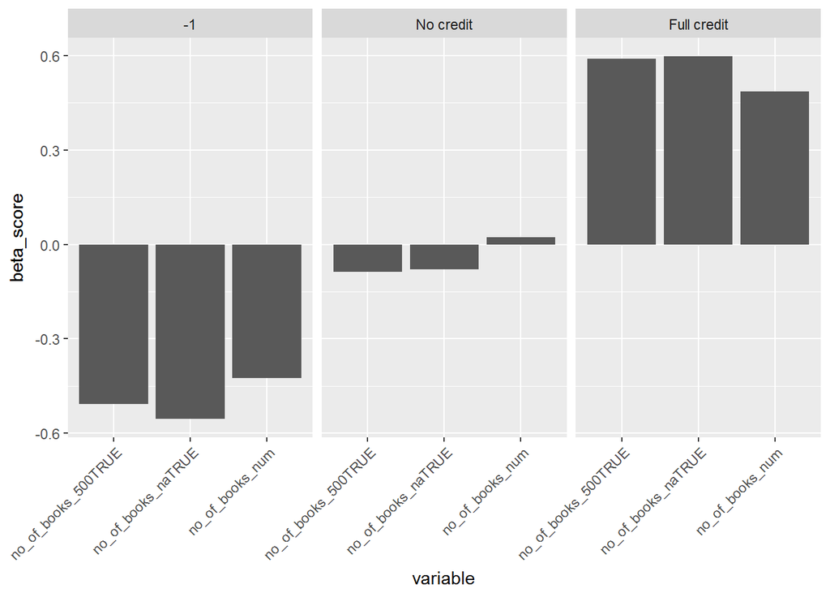

```r
coefs <- coefs_score(model$coefficients)
ggplot(coefs[grep("no_of_books", coefs$variable), ], aes(y = beta_score, x = variable)) + geom_bar(stat = "identity") + facet_wrap(~ score) + theme(axis.text.x=element_text(angle = 45, hjust = 1))
```

Widać, że u osób, które rozwiązały zadanie poprawnie wszystkie zmienne związane z liczbą książek sa dodatnio związane z czasem rozwiązywania. Zależność ta jest bliska zera dla osób, które źle rozwiązały zadanie i ujemna dla tych, dla których nie ma informacji o punktacji.

Porównajmy teraz dwa nowe modele z wyjściowym pod względem kryteriów informacyjnych:

```r
data.frame(stary = crit_base, nowy = nowy, nowy_plus_6 = nowy2); rm(model, nowy, nowy2)
```

```
##      stary   nowy nowy_plus_6
## AIC 510716 511184      510815
## BIC 514321 514661      514324
```

```r
model <- lm(time.log ~ score*(task + edu_resources + no_of_books_500 + wealth + book_id + father_edu) + mother_edu + female + country, data = probka)
anova(model)[grep("no_of_books", rownames(anova(model))),]
```

```
## Analysis of Variance Table
##
## Response: time.log
##                       Df Sum Sq Mean Sq F value  Pr(>F)
## no_of_books_500        1   10.6   10.57    37.7 8.3e-10 ***
## score:no_of_books_500  2   18.0    9.01    32.1 1.1e-14 ***
## ---
## Signif. codes:  0 '***' 0.001 '**' 0.01 '*' 0.05 '.' 0.1 ' ' 1
```

```r
c(AIC = AIC(model), BIC = BIC(model))
```

```
##    AIC    BIC
## 512382 515826
```

Jak widać, uwzględnienie jedynie `no_of_books_500` jeszcze bardziej pogarsza model pod względem kryteriów informacyjnych. Z tego względu powracamy do wyjściowego kodowania zmiennej `no_of_books`.

## 3.3 Wykształcenie matki i ojca

Kodowanie i transformacje zmiennych `mother_edu` i `father_edu` będziemy rozważać równolegle ze względu na to, że zmienne te mają taką samą strukturę, więc warto sprawdzić skutek jednoczesnej ich transformacji. Mają one następujący rozkład w naszej próbie:

```r
rbind(mother = table(probka$mother_edu), father = table(probka$father_edu))
```

```
##           0    -1     1     2     3     4     5     6
## mother 9055  6734 18727 41063 26511 82098 48398 94307
## father 9451 11574 18857 43598 28905 78729 45444 90335
```

Rozkłady te wyglądają podobnie z wyjątkiem wyraźnie większej liczby braków danych w przypadku wykształcenia ojca co może odzwierciedlać fakt, że dzieci częściej wychowywane są przez samotne matki niż przez samotnych ojców.

### 3.3.1 Kodowanie ilościowe

Najpierw rozważymy kodowanie ilościowe obu zmiennych z dodaniem zmiennej wskazującej braki danych i oszacujemy trzy modele uwzgledniające takie kodowanie dla jednej lub obu zmiennych.

```r
probka$mother_edu_na <- probka$mother_edu == "-1"
probka$mother_edu_num <- as.numeric(as.character(probka$mother_edu))
probka[probka$mother_edu_num == -1, "mother_edu_num"] <- mean(probka[probka$mother_edu_num != -1, "mother_edu_num"])
probka$father_edu_na <- probka$father_edu == "-1"
probka$father_edu_num <- as.numeric(as.character(probka$father_edu))
probka[probka$father_edu_num == -1, "father_edu_num"] <- mean(probka[probka$father_edu_num != -1, "father_edu_num"])

model <- lm(time.log ~ score*(task + edu_resources + no_of_books + wealth + book_id + father_edu_num + father_edu_na) + mother_edu_num + mother_edu_na + female + country, data = probka)
model_both <- c(AIC = AIC(model), BIC = BIC(model))
model <- lm(time.log ~ score*(task + edu_resources + no_of_books + wealth + book_id + father_edu) + mother_edu_num + mother_edu_na + female + country, data = probka)
model_mom <- c(AIC = AIC(model), BIC = BIC(model))
model <- lm(time.log ~ score*(task + edu_resources + no_of_books + wealth + book_id + father_edu_num + father_edu_na) + mother_edu + female + country, data = probka)
model_dad <- c(AIC = AIC(model), BIC = BIC(model))
data.frame(stary = crit_base, model_both = model_both, model_dad = model_dad, model_mom = model_mom)
```

```
##      stary model_both model_dad model_mom
## AIC 510716     510797    510705    510785
## BIC 514321     514188    514149    514336
```

Oba kryteria informacyjne wskazują na model z kodowaniem ilościowym wykształcenia ojca jako na najlepszy spośród trzech rozważanych powyżej i bazowego. Aby potwierdzić sensowność ilościowego kodowania wykształcenia ojca szacujemy model z kontrastami wielomianowymi dla tego wykształcenia po zakodowaniu `father_edu = "-1"` jako poziomu 4 ze względu na to, że średnia z próby `father_edu` wśród tych, dla których nie brakowało tej danej, wyniosła 4.05 (nowa zmienna to `father_edu_new`).

```r
probka$father_edu_new <- probka$father_edu
probka$father_edu_new[probka$father_edu_new == "-1"] <- "4"
probka$father_edu_new <- droplevels(probka$father_edu_new)
model <- lm(time.log ~ score*(task + edu_resources + no_of_books + wealth + book_id + father_edu_na + father_edu_new) + mother_edu + female + country, data = probka, contrasts = list(father_edu_new = contr.poly(7)))
df <- as.data.frame(summary(model)$coefficients); df$variable <- rownames(df)
(df <- cbind(df[, ], czy_istotne = as.numeric(df[, 4] < 0.05)))[grep("father_edu_new", rownames(df)), c(1,4,6)]
```

```
##                                    Estimate  Pr(>|t|) czy_istotne
## father_edu_new.L                   0.013246 3.819e-02           1
## father_edu_new.Q                   0.003883 4.904e-01           0
## father_edu_new.C                   0.008237 1.056e-01           0
## father_edu_new^4                  -0.011732 2.754e-02           1
## father_edu_new^5                   0.009458 3.010e-02           1
## father_edu_new^6                   0.006584 1.519e-01           0
## score-1:father_edu_new.L           0.042696 8.187e-06           1
## scoreFull credit:father_edu_new.L -0.025521 8.857e-03           1
## score-1:father_edu_new.Q           0.006786 4.328e-01           0
## scoreFull credit:father_edu_new.Q -0.002307 7.934e-01           0
## score-1:father_edu_new.C          -0.015362 5.242e-02           0
## scoreFull credit:father_edu_new.C -0.009625 2.270e-01           0
## score-1:father_edu_new^4           0.006272 4.411e-01           0
## scoreFull credit:father_edu_new^4  0.011691 1.415e-01           0
## score-1:father_edu_new^5          -0.004897 4.640e-01           0
## scoreFull credit:father_edu_new^5 -0.005728 3.772e-01           0
## score-1:father_edu_new^6          -0.007467 2.749e-01           0
## scoreFull credit:father_edu_new^6 -0.002078 7.481e-01           0
```

Ostatecznie, jako nowy model wyjściowy przyjmujemy ten, w którym wykształcenie ojca traktujemy jako zmienną ciągłą:

```r
modelBase <- lm(time.log ~ score*(task + edu_resources + no_of_books + wealth + book_id + father_edu_num + father_edu_na) + mother_edu + female + country, data = probka)
coefs <- coefs_score(modelBase$coefficients)
crit_base <- c(AIC = AIC(modelBase), BIC = BIC(modelBase))
```

### 3.3.2 Kontrasty wielomianowe

Poprawiliśmy już nasz model pod względem sposobu kodowania wykształcenia ojca, jednak nie udało się to nam w przypadku wykształcenia matki. Na poniższym wykresie przedstawiamy oszacowania parametrów dla tej zmiennej – nie widać tutaj monotoniczności (po wyłączeniu dwóch skrajnych kategorii można zauważyć trend kwadratowy), więc nic dziwnego, że założenie o liniowości `mother_edu` nie poprawiało kryteriów informacyjnych modelu.

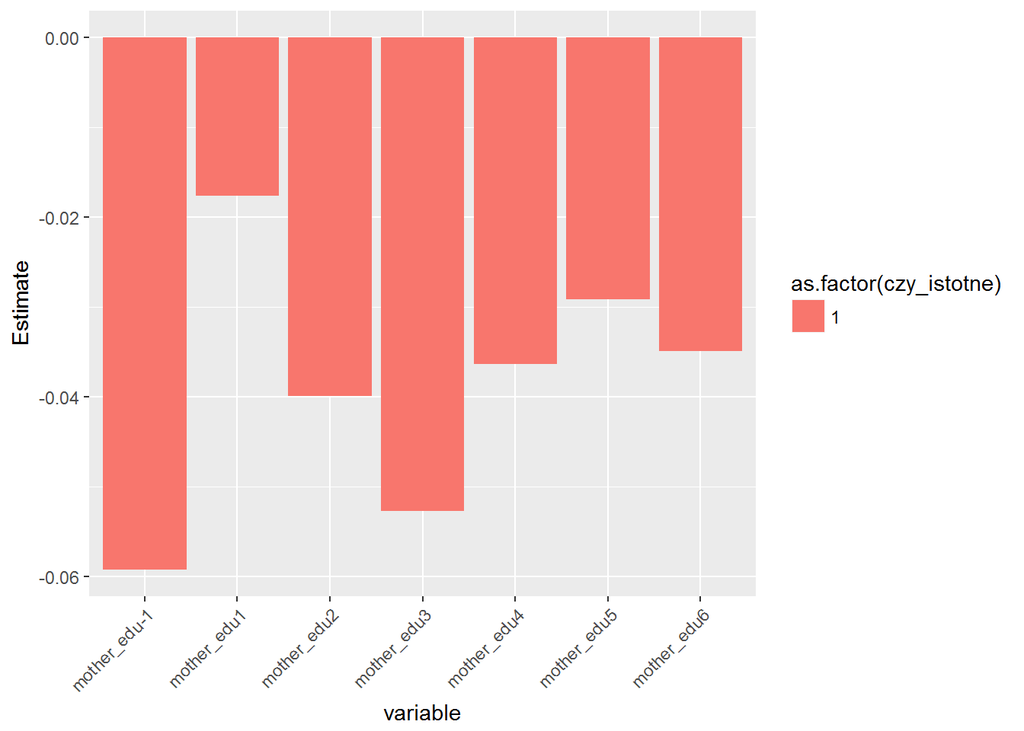

```r
ggplot(df[grep("mother_edu", df$variable), ], aes(y = Estimate, x = variable, fill = as.factor(czy_istotne))) + geom_bar(stat = "identity") + theme(axis.text.x = element_text(angle = 45, hjust = 1))
```

Zastosowanie kontrastów wielomianowych do wykształcenia matki (po podobnych przekształceniach co wcześniej, prowadzących do zmiennej `mother_edu_new`) potwierdza nasze przypuszczenia o występowaniu trendu kwadratowego, jednak po wyłączeniu kategorii “-1” (brak danych) istotne pozostają trendy wszystkich stopni oprócz piątego, co może być powodowane odstającym charakterem kategorii “6”.

```r
probka$mother_edu_new <- probka$mother_edu
probka$mother_edu_new[probka$mother_edu_new == "-1"] <- "4"
probka$mother_edu_new <- droplevels(probka$mother_edu_new)
model <- lm(time.log ~ score*(task + edu_resources + no_of_books + wealth + book_id + father_edu_num + father_edu_na) + mother_edu_na + mother_edu_new + female + country, data = probka, contrasts = list(mother_edu_new = contr.poly(7)))
df <- as.data.frame(summary(model)$coefficients)
cbind(df[, ], czy_istotne = as.numeric(df[, 4] < 0.05))[grep("mother_edu_new", rownames(df)), ]
```

```
##                   Estimate Std. Error t value  Pr(>|t|) czy_istotne
## mother_edu_new.L -0.024933   0.004579  -5.445 5.199e-08           1
## mother_edu_new.Q  0.030792   0.003735   8.245 1.654e-16           1
## mother_edu_new.C -0.010980   0.003351  -3.277 1.051e-03           1
## mother_edu_new^4 -0.015393   0.003432  -4.485 7.307e-06           1
## mother_edu_new^5  0.004548   0.002775   1.639 1.012e-01           0
## mother_edu_new^6  0.006310   0.002903   2.173 2.974e-02           1
```

Poniżej przeprowadzamy estymację z kontrastami wielomianowymi po wprowadzeniu do modelu osobnej zmiennej wskazującej kategorię “6”. Jak widać w tabeli poniżej powoduje to eliminację istotności trendu kwadratowego dla zmiennej `mother_edu_new`, ale trend trzeciego i czwartego stopnia pozostają istotne, co oznacza, że nie jest to dobre podejście.

```r
probka$mother_edu6 <- probka$mother_edu == "6"
model <- lm(time.log ~ score*(task + edu_resources + no_of_books + wealth + book_id + father_edu_num + father_edu_na) + mother_edu_na + mother_edu6 + mother_edu_new + female + country, data = probka, contrasts = list(mother_edu_new = contr.poly(7)))
df <- as.data.frame(summary(model)$coefficients)
cbind(df, czy_istotne = as.numeric(df[, 4] < 0.05))[grep("mother_edu", rownames(df)), ]
```

```
##                   Estimate Std. Error t value Pr(>|t|) czy_istotne
## mother_edu_naTRUE -0.02328   0.007633  -3.050 0.002290           1
## mother_edu6TRUE    0.19181   0.088251   2.173 0.029744           1
## mother_edu_new.L  -0.13368   0.050414  -2.652 0.008010           1
## mother_edu_new.Q  -0.07385   0.047496  -1.555 0.119974           0
## mother_edu_new.C  -0.08929   0.036288  -2.461 0.013874           1
## mother_edu_new^4  -0.06176   0.021825  -2.830 0.004655           1
## mother_edu_new^5  -0.01638   0.010583  -1.548 0.121689           0
```

```r
rm(model)
```

### 3.3.3 Łączenie poziomów

Naszym ostatnim podejściem do kodowania wykształcenia matki jest próba połączenia podobnych do siebie poziomów. W tym celu wykonamy test post hoc Tukey’a aby sprawdzić, czy są poziomy, które nie różnią się od siebie istotnie.

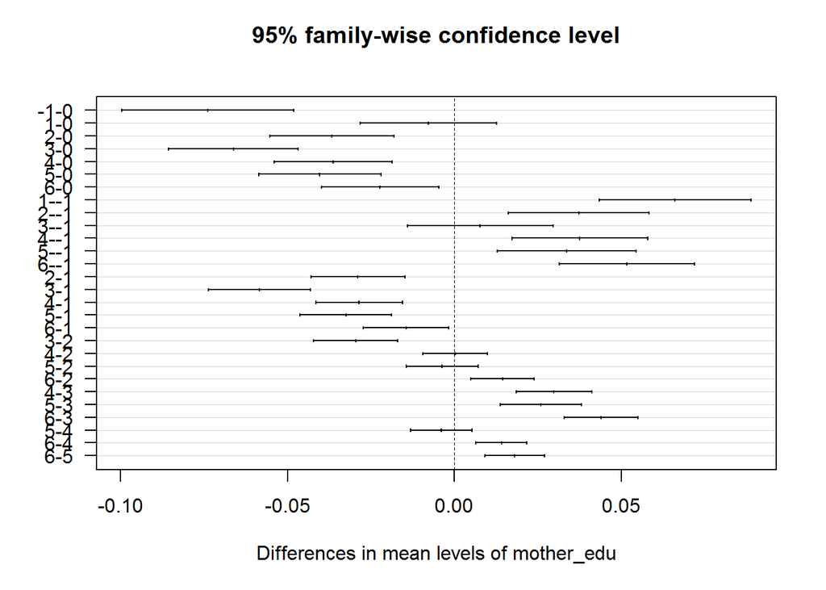

```r
plot(TukeyHSD(aov(time.log ~ score*(task + edu_resources + no_of_books + wealth + book_id + father_edu_num + father_edu_na) + mother_edu + female + country, data = probka), which = "mother_edu"), las = 1)
```

```r
probka$mother_edu_merge <- factor(as.numeric(as.character(probka$mother_edu)), levels = -1:6, labels = c(-1, "01", "01", 2, 3, "45", "45", 6))
probka$mother_edu_merge <- droplevels(probka$mother_edu_merge)
probka$mother_edu_merge <- relevel(probka$mother_edu_merge, ref = "01")
model <- lm(time.log ~ score*(task + edu_resources + no_of_books + wealth + book_id + father_edu_num + father_edu_na) + mother_edu_merge + female + country, data = probka)
nowy <- c(AIC = AIC(model), BIC = BIC(model))

probka$mother_edu_merge_13 <- factor(as.numeric(as.character(probka$mother_edu)), levels = -1:6, labels = c("-13", "01", "01", 2, "-13", "45", "45", 6))
probka$mother_edu_merge_13 <- droplevels(probka$mother_edu_merge_13)
probka$mother_edu_merge_13 <- relevel(probka$mother_edu_merge_13, ref = "01")
model <- lm(time.log ~ score*(task + edu_resources + no_of_books + wealth + book_id + father_edu_num + father_edu_na) + mother_edu_merge_13 + female + country, data = probka)
nowy_13 <- c(AIC = AIC(model), BIC = BIC(model))

data.frame(stary = crit_base, nowy = nowy, nowy_13 = nowy_13)
```

```
##      stary   nowy nowy_13
## AIC 510705 510711  510710
## BIC 514149 514135  514122
```

Na podstawie powyższych kryteriów informacyjnych można stwierdzić, że w obu przypadkach połączenie wybranych kategorii powoduje nieznaczne pogorszenie modelu według AIC i polepszenie według BIC. Warto jednak zauważyć, że zmiany kryteriów informacyjnych są tutaj niewielkie (w porównaniu do obserwowanych na poprzednich etapach analizy), więc ostatecznie decydujemy się pozostać przy wyjściowym kodowaniu wykształcenia matki.

### 3.3.4 Minimalne i maksymalne wykształcenie rodziców

Alternatywnym podejściem do uwzględnienia w modelu wykształcenia rodziców jest wyróżnienie maksymalnego lub minimalnego wykształcenia rodziców, gdyż można podejrzewać, że rozróżnianie rodziców ze względu na płeć nie jest istotne przy kształtowaniu zdolności dziecka do rozwiązywania zadań – rozróżnienie rodziców ze względu na ich poziom wykształcenia (niższy lub wyższy) wydaje się w tym kontekście bardziej adekwatne.

Poniżej tworzymy model, w którym `edu_max` jest w interakcji ze `score` (zamiast `father_edu`), a `edu_min` nie (sprawdziliśmy, że interakcja z pierwszą z tych dwóch zmiennych wyjaśnia więcej zmienności, a w ten sposób mamy model z taką samą liczbą parametrów jak wcześniej, więc porównanie będzie dotyczyło jedynie tego jak dobrze każdy z nich wyjaśnia zmieność zmiennej objaśnianej). W przypadku zmiennej `edu_max` jako kategorię bazową bierzemy najwyższy poziom wykształcenia ze względu na dużą liczbę obserwacji dla niej.

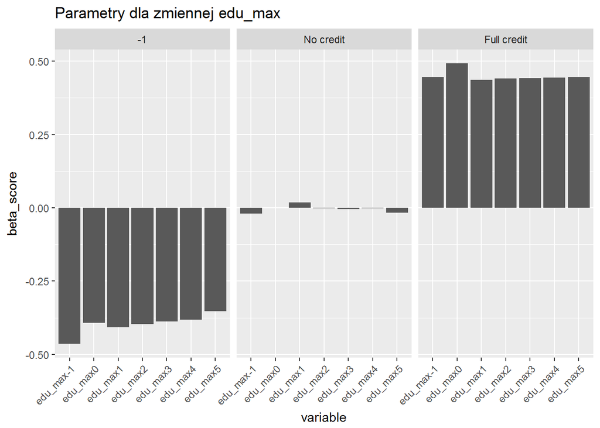

```r
probka[probka$mother_edu == "-1", "mother_edu"] <- NA
probka[probka$father_edu == "-1", "father_edu"] <- NA
probka$edu_min <- as.character(pmin(as.numeric(as.character(probka$father_edu)), as.numeric(as.character(probka$mother_edu)), na.rm = TRUE))
probka[is.na(probka$edu_min), "edu_min"] <- "-1"
probka$edu_min <- as.factor(probka$edu_min)
probka$edu_min <- relevel(probka$edu_min, ref = "0")
probka$edu_max <- as.character(pmax(as.numeric(as.character(probka$father_edu)), as.numeric(as.character(probka$mother_edu))))
probka[is.na(probka$edu_max), "edu_max"] <- "-1"
probka$edu_max <- as.factor(probka$edu_max)
probka$edu_max <- relevel(probka$edu_max, ref = "6")
model <- lm(time.log ~ score*(task + edu_resources + no_of_books + wealth + book_id + edu_max) + edu_min + female + country, data = probka)
nowy <- c(AIC = AIC(model), BIC = BIC(model))
coefs <- coefs_score(model$coefficients)
ggplot(coefs[grep("edu_max", coefs$variable), ], aes(y = beta_score, x = variable)) + geom_bar(stat = "identity") + facet_wrap(~ score) + theme(axis.text.x=element_text(angle = 45, hjust = 1)) + ggtitle("Parametry dla zmiennej edu_max")
```

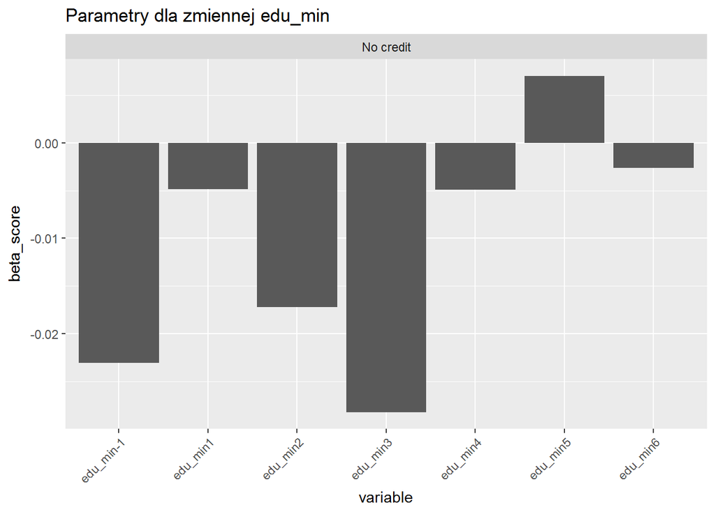

```r
ggplot(coefs[grep("edu_min", coefs$variable), ], aes(y = beta_score, x = variable)) + geom_bar(stat = "identity") + facet_wrap(~ score) + theme(axis.text.x=element_text(angle = 45, hjust = 1)) + ggtitle("Parametry dla zmiennej edu_min")
```

Na powyższym wykresie widzimy, że różnice oszacowań parametrów dla kategorii zmiennej `edu_max` są dość małe, a uznanie zależności za monotoniczną nie byłoby dużym uproszczeniem, więc to właśnie robimy poniżej (w ten sposób ten nowy model jest całkowicie analogiczny do wyjściowego, gdyż mamy jedną zmienną kodowaną ilościowo i jedną jakościowo). Warto zauważyć, że w przypadku `edu_min` nie widać żadnej monotoniczności oszacowań – jest to znacznie wyraźniejsze niż dla wykształcenia matki w wyjściowym modelu.

```r
probka$edu_max_na <- probka$edu_max == "-1"
probka$edu_max_num <- as.numeric(as.character(probka$edu_max))
probka[probka$edu_max_num == -1, "edu_max_num"] <- mean(probka[probka$edu_max_num != -1, "edu_max_num"])
model <- lm(time.log ~ score*(task + edu_resources + no_of_books + wealth + book_id + edu_max_num + edu_max_na) + edu_min + female + country, data = probka)
data.frame(stary = crit_base, nowy = nowy, nowy_max_num = c(AIC = AIC(model), BIC = BIC(model)))
```

```
##      stary   nowy nowy_max_num
## AIC 510705 510724       510723
## BIC 514149 514329       514167
```

Z powyższej tabeli kryteriów informacyjnych wynika, że uwzględnienie minimalnego i maksymalnego wykształcenia rodziców nie polepsza modelu w stosunku do tego uwzględniającego wykształcenie matki i ojca (według żadnego z kryteriów), zatem powracamy do poprzedniej wersji modelu.

# 4 Transformacja zmiennej zależnej

## 4.1 Reszty modelu wyjściowego

Na poniższym wykresie prezentujemy rozkład reszt modelu wyjściowego w porównaniu do rozkładu normalnego (skośność wynosi -0.1598, a kurtoza 3.723). W modelu tym zastosowaliśmy transformację logarytmiczną z przesunięciem 0.4108118.

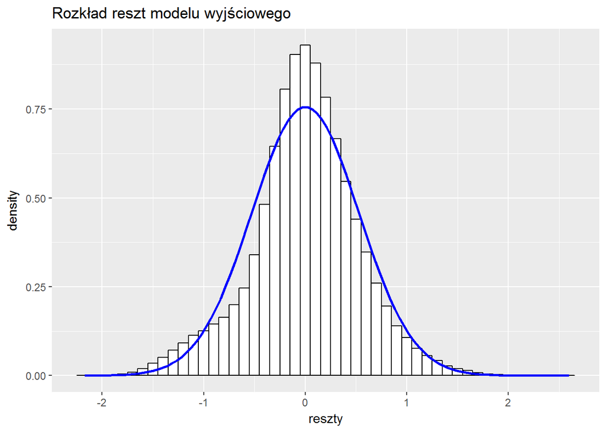

```r
rm(model, df, coefs)
crit_base <- c(AIC = AIC(modelBase), BIC = BIC(modelBase))
ggplot(data.frame(reszty = modelBase$residuals), aes(x = reszty)) + geom_histogram(aes(y=..density..), binwidth = 0.1, color = "black", fill = "white") + stat_function(fun = dnorm, args = list(mean = mean(modelBase$residuals), sd = sd(modelBase$residuals)), color = "blue", size = 1) + ggtitle("Rozkład reszt modelu wyjściowego")
```

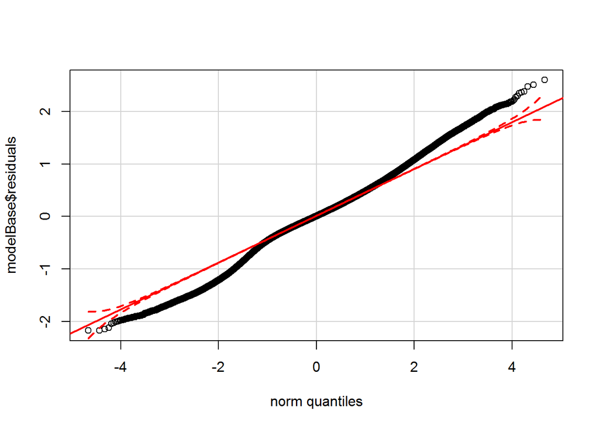

```r
qqPlot(modelBase$residuals)
```

```r
ad.test(modelBase$residuals)
```

```
##
##  Anderson-Darling normality test
##
## data:  modelBase$residuals
## A = 1200, p-value <2e-16
```

## 4.2 Transformacja Boxa-Coxa

Poniżej przedstawiamy wykres log-wiarygodności modelu w zależności od zastosowanej transformacji Boxa-Coxa.

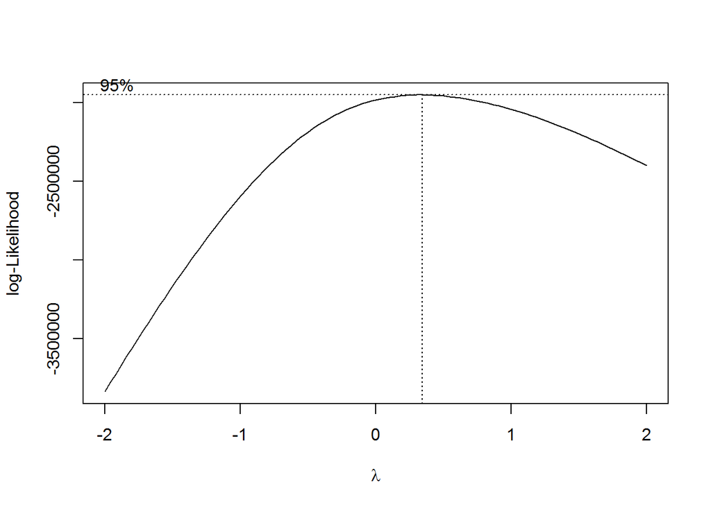

```r
modelBase <- lm(time ~ score*(task + edu_resources + no_of_books + wealth + book_id + father_edu_num + father_edu_na) + mother_edu + female + country, data = probka)
bc <- boxcox(modelBase, plotit = TRUE); rm(modelBase)
```

```r
wykladnik <- bc$x[which.max(bc$y)] # optymalny wykładnik
```

Optymalny wykładnik (spośród rozpatrywanej siatki wykładników) dla tej transformacji wynosi 0.3434. Poniżej przedstawiamy graficznie rozkład reszt modelu po takiej transformacji:

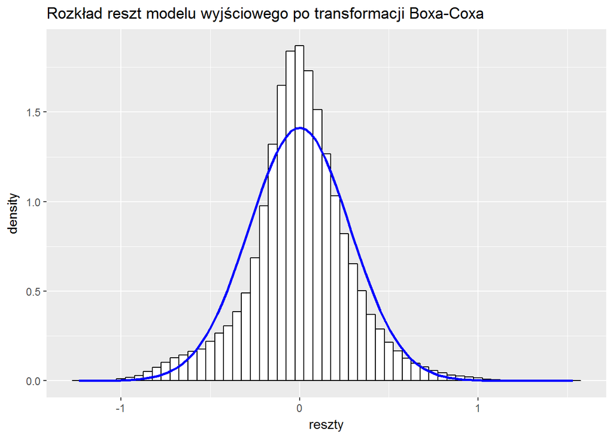

```r
probka$time.bc <- probka$time^wykladnik
modelBase_bc <- lm(time.bc ~ score*(task + edu_resources + no_of_books + wealth + book_id + father_edu_num + father_edu_na) + mother_edu + female + country, data = probka)
ggplot(data.frame(reszty = modelBase_bc$residuals), aes(x = reszty)) + geom_histogram(aes(y=..density..), binwidth = 0.05, color = "black", fill = "white") + stat_function(fun = dnorm, args = list(mean = mean(modelBase_bc$residuals), sd = sd(modelBase_bc$residuals)), color = "blue", size = 1) + ggtitle("Rozkład reszt modelu wyjściowego po transformacji Boxa-Coxa")
```

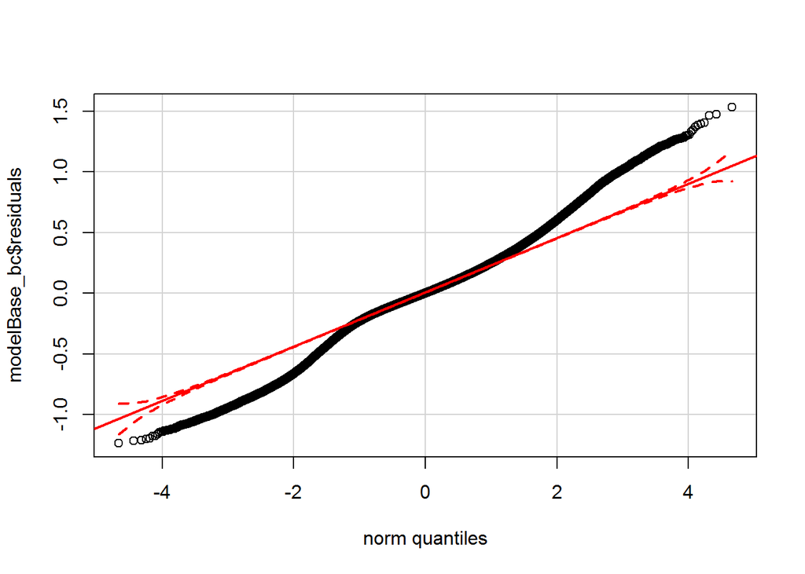

```r
qqPlot(modelBase_bc$residuals)
```

```r
data.frame(wyjsciowy = crit_base, nowy = c(AIC = AIC(modelBase_bc), BIC = BIC(modelBase_bc)))
```

```
##     wyjsciowy   nowy
## AIC    510705  99846
## BIC    514149 103273
```

Co ciekawe, patrząc na wykresy wydaje się, że dopasowanie reszt modelu po transformacji Boxa-Coxa do rozkładu normalnego jest gorsze, niż w modelu wyjściowym (potwierdza to również wysoka kurtoza 4.317, choć skośność jest trochę lepsza: -0.0804), jednak kryteria informacyjne są znacznie niższe w przypadku tego modelu. Niezmiennie jednak odrzucamy hipotezę zerową o normalności reszt w teście Andersona-Darlinga:

```r
ad.test(modelBase_bc$residuals); rm(modelBase_bc) # test Andersona Darlinga
```

```
##
##  Anderson-Darling normality test
##
## data:  modelBase_bc$residuals
## A = 1900, p-value <2e-16
```

## 4.3 Transformacja logarytmiczna z przesunięciem

Poniżej przedstawiamy wykres log-wiarygodności modelu w zależności od przesunięcia zastosowanego przed wykonaniem transformacji logarytmicznej.

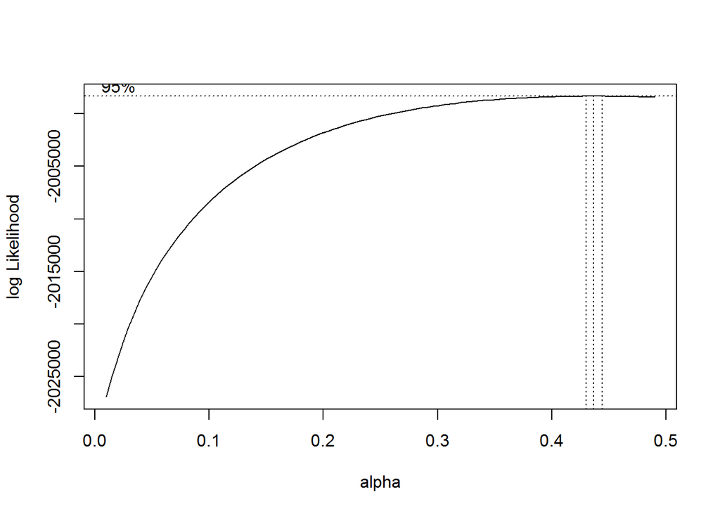

```r
modelBase <- lm(time ~ score*(task + edu_resources + no_of_books + wealth + book_id + father_edu_num + father_edu_na) + mother_edu + female + country, data = probka)
lt <- logtrans(modelBase, alpha = seq(0.01, 0.5, by = 0.03), plotit = TRUE); rm(modelBase)
```

```r
przesuniecie <- lt[[1]][which.max(lt[[2]])] # optymalne przesunięcie
```

Optymalne przesunięcie (spośród rozpatrywanej siatki przesunięć) dla transformacji logarytmicznej wynosi 0.4367, a reszty po jej zastosowaniu mają następujący rozkład:

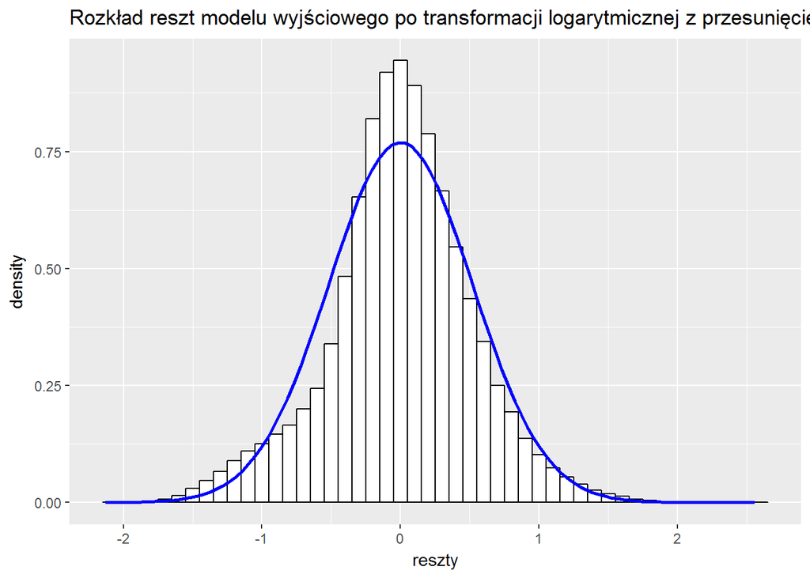

```r
probka$time.log2 <- log(probka$time + przesuniecie)
modelBase_lt <- lm(time.log2 ~ score*(task + edu_resources + no_of_books + wealth + book_id + father_edu_num + father_edu_na) + mother_edu + female + country, data = probka)
ggplot(data.frame(reszty = modelBase_lt$residuals), aes(x = reszty)) + geom_histogram(aes(y=..density..), binwidth = 0.1, color = "black", fill = "white") + stat_function(fun = dnorm, args = list(mean = mean(modelBase_lt$residuals), sd = sd(modelBase_lt$residuals)), color = "blue", size = 1) + ggtitle("Rozkład reszt modelu wyjściowego po transformacji logarytmicznej z przesunięciem")
```

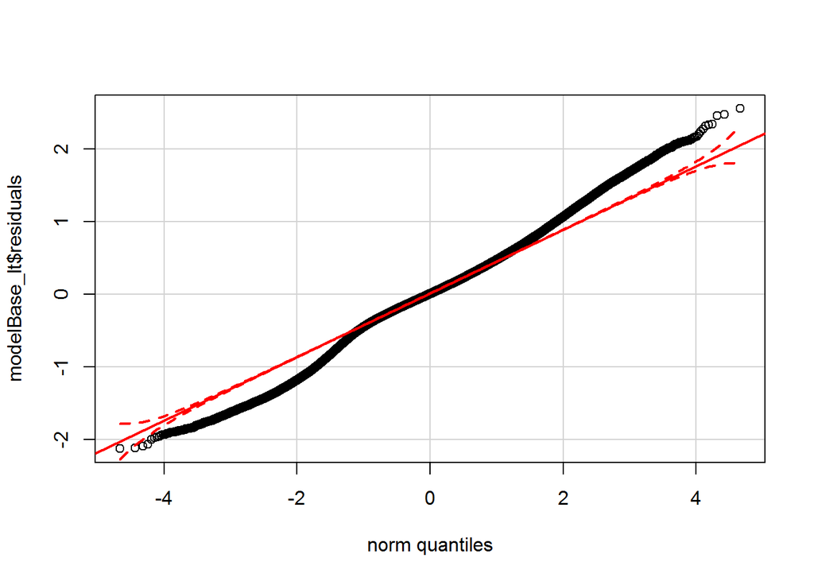

```r
qqPlot(modelBase_lt$residuals)
```

```r
data.frame(wyjsciowy = crit_base, nowy = c(AIC = AIC(modelBase_lt), BIC = BIC(modelBase_lt)))
```

```
##     wyjsciowy   nowy
## AIC    510705 488387
## BIC    514149 491815
```

Jak widać, dopasowanie rozkładu normalnego do rozkładu naszej zmiennej po nowej transformacji jest podobne do tej z modelu wyjściowego, dla którego przesunięcie wyniosło 0.4108118, czyli niewiele mniej. Choć kryteria informacyjne są w tym przypadku znacznie wyższe niż przy transformacji Boxa-Coxa, to graficznie dopasowanie reszt do rozkładu normalnego wydaje się lepsze i potwierdzaja to, jak wcześniej, kurtoza 3.7206, ale nie skośność -0.1363. Wciąż nie udaje nam się spełnić założenia o normalności rozkładu reszt:

```r
ad.test(modelBase_lt$residuals); rm(modelBase_lt) # test Andersona Darlinga
```

```
##
##  Anderson-Darling normality test
##
## data:  modelBase_lt$residuals
## A = 1100, p-value <2e-16
```

## 4.4 Wybór transformacji

Ostatecznie, mając do wyboru:

- transformację Boxa-Coxa, która prowadzi do prawie pięciokrotnie niższych kryteriów informacyjnych i reszt niemal symetrycznych lecz trochę spiczastych
- transformację logarytmiczną z przesunięciem, która prowadzi do wysokich kryteriów informacyjnych, dwa razy bardziej skośnych reszt o spiczastości niemalże równej rozkładowi normalnemu,

decydujemy się na lepsze dopasowanie modelu do danych, a więc wybieramy na podstawie kryteriów informacyjnych transformację Boxa-Coxa, co prowadzi do następującego modelu:

```r
modelBase <- lm(time.bc ~ score*(task + edu_resources + no_of_books + wealth + book_id + father_edu_num + father_edu_na) + mother_edu + female + country, data = probka)
save(probka, file = "Projekt_probka.rda") # Zapisujemy ostateczną próbkę
anova(modelBase)
```

```
## Analysis of Variance Table
##
## Response: time.bc
##                          Df Sum Sq Mean Sq F value  Pr(>F)
## score                     2    706     353 4420.88 < 2e-16 ***
## task                     43   1951      45  567.91 < 2e-16 ***
## edu_resources             1     11      11  135.11 < 2e-16 ***
## no_of_books               6     33       5   68.62 < 2e-16 ***
## wealth                    1    147     147 1837.37 < 2e-16 ***
## book_id                  35    412      12  147.48 < 2e-16 ***
## father_edu_num            1      0       0    5.57   0.018 *
## father_edu_na             1      3       3   37.88 7.5e-10 ***
## mother_edu                6     18       3   37.94 < 2e-16 ***
## female                    1     31      31  393.13 < 2e-16 ***
## country                  54    571      11  132.35 < 2e-16 ***
## score:task               78   1399      18  224.43 < 2e-16 ***
## score:edu_resources       2     48      24  297.49 < 2e-16 ***
## score:no_of_books        12     86       7   89.62 < 2e-16 ***
## score:wealth              2      6       3   34.45 1.1e-15 ***
## score:book_id            70     46       1    8.23 < 2e-16 ***
## score:father_edu_num      2      6       3   39.11 < 2e-16 ***
## score:father_edu_na       2      4       2   22.63 1.5e-10 ***
## Residuals            319839  25554       0
## ---
## Signif. codes:  0 '***' 0.001 '**' 0.01 '*' 0.05 '.' 0.1 ' ' 1
```